# Constrained ordination

Gavin Simpson

August 7th, 2024

# Canonical Correspondence Analysis

In this part of the practical you will use the `cca()` function from package **vegan** to perform a canonical correspondence analysis (CCA) of the diatom species data and the environmental data. Begin by loading **vegan** and reading in the data sets:

```r
library("vegan")
url_env <- "https://bit.ly/pondsenv"
env <- read.csv(url(url_env))

url_diat <- "https://bit.ly/pondsdiat"
diat <- read.csv(url(url_diat))
```

The ponds are numbered numerically in the form X???, the species are encoded using DIATCODE and environmental variable codes should be self explanatory:

```r
rownames(diat)
```

```
##  [1] "X004" "X007" "X031" "X034" "X037" "X042" "X050" "X053"
##  [9] "X057" "X058" "X065" "X069" "X073" "X074" "X076" "X079"
## [17] "X082" "X083" "X085" "X086" "X098" "X100" "X101" "X105"
## [25] "X107" "X108" "X112" "X113" "X114" "X120"
```

```r
names(diat)
```

```
##  [1] "AC001A" "AC013A" "AC013E" "AM011A" "AM012A" "AS001A"
##  [7] "AU002A" "AU003B" "CC001A" "CC002A" "CC9997" "CM004A"
## [13] "CO001A" "CY002A" "CY003A" "CY009A" "CY011A" "FR001A"
## [19] "FR002A" "FR002C" "FR006A" "FR006E" "FR009B" "FR018A"
## [25] "FR019A" "GO013A" "NA004A" "NA007A" "NA022A" "NA042A"
## [31] "NA114A" "NI009A" "NI014A" "NI015A" "NI083A" "NI196A"
## [37] "NI9969" "NI9971" "OP001A" "ST001A" "ST002A" "ST010A"
## [43] "SU016A" "SY002A" "SY003A" "SY003C" "SY010A" "UN9992"
```

```r
names(env)
```

```
##  [1] "pH"           "Conductivity" "Alkalinity"   "TP"
##  [5] "SiO2"         "NO3"          "Na"           "K"
##  [9] "Mg"           "Ca"           "Cl"           "SO4"
## [13] "Chla"         "Secchid"      "Maxdepth"
```

**vegan** has a nice formula interface, so it works in a similar way to the notation you used in the two regression practical classes. To fit a CCA model to the diatom and environmental data use the `cca()` function:

```r
ponds.cca <- cca(diat ~ ., data = env)
ponds.cca
```

```
##
## Call: cca(formula = diat ~ pH + Conductivity + Alkalinity +
## TP + SiO2 + NO3 + Na + K + Mg + Ca + Cl + SO4 + Chla +
## Secchid + Maxdepth, data = env)
##
##               Inertia Proportion Rank
## Total           5.812      1.000
## Constrained     3.273      0.563   15
## Unconstrained   2.539      0.437   14
##
## Inertia is scaled Chi-square
##
## Eigenvalues for constrained axes:
##  CCA1  CCA2  CCA3  CCA4  CCA5  CCA6  CCA7  CCA8  CCA9 CCA10
## 0.595 0.406 0.338 0.324 0.303 0.238 0.206 0.190 0.151 0.133
## CCA11 CCA12 CCA13 CCA14 CCA15
## 0.126 0.100 0.080 0.053 0.030
##
## Eigenvalues for unconstrained axes:
##   CA1   CA2   CA3   CA4   CA5   CA6   CA7   CA8   CA9  CA10
## 0.445 0.316 0.287 0.246 0.239 0.205 0.174 0.149 0.119 0.103
##  CA11  CA12  CA13  CA14
## 0.085 0.084 0.052 0.035
```

The formula means the diatom data matrix `diat` is modelled by everything in the environmental data matrix `env`. We use the data argument to inform R of where to look for the explanatory variables. The `.` is an **R** shortcut that saves you from having to type out the full formula.

**What are the values of $\lambda_1$ and $\lambda_2$, the eigenvalues for constrained axes one and two?**

**What is the total variance (inertia) in the diatom data?**

**What proportion of the total variance is explained by the environmental variables?**

**What proportion of the variance remains un-explained?**

The `summary()` method provides further, detailed results of the CCA:

```r
summary(ponds.cca)
```

```
##
## Call:
## cca(formula = diat ~ pH + Conductivity + Alkalinity + TP + SiO2 +      NO3 + Na + K + Mg + Ca + Cl + SO4 + Chla + Secchid + Maxdepth,      data = env)
##
## Partitioning of scaled Chi-square:
##               Inertia Proportion
## Total            5.81      1.000
## Constrained      3.27      0.563
## Unconstrained    2.54      0.437
##
## Eigenvalues, and their contribution to the scaled Chi-square
##
## Importance of components:
##                        CCA1   CCA2   CCA3   CCA4   CCA5  CCA6
## Eigenvalue            0.595 0.4057 0.3380 0.3235 0.3027 0.238
## Proportion Explained  0.102 0.0698 0.0582 0.0557 0.0521 0.041
## Cumulative Proportion 0.102 0.1721 0.2303 0.2859 0.3380 0.379
##                         CCA7   CCA8  CCA9 CCA10  CCA11  CCA12
## Eigenvalue            0.2063 0.1900 0.151 0.133 0.1262 0.0997
## Proportion Explained  0.0355 0.0327 0.026 0.023 0.0217 0.0172
## Cumulative Proportion 0.4145 0.4472 0.473 0.496 0.5179 0.5351
##                        CCA13   CCA14  CCA15    CA1    CA2    CA3
## Eigenvalue            0.0804 0.05275 0.0297 0.4449 0.3158 0.2868
## Proportion Explained  0.0138 0.00908 0.0051 0.0765 0.0543 0.0493
## Cumulative Proportion 0.5489 0.55800 0.5631 0.6396 0.6940 0.7433
##                          CA4    CA5    CA6    CA7    CA8    CA9
## Eigenvalue            0.2464 0.2391 0.2046 0.1739 0.1492 0.1191
## Proportion Explained  0.0424 0.0411 0.0352 0.0299 0.0257 0.0205
## Cumulative Proportion 0.7857 0.8268 0.8620 0.8919 0.9176 0.9381
##                         CA10   CA11   CA12    CA13    CA14
## Eigenvalue            0.1029 0.0855 0.0842 0.05183 0.03540
## Proportion Explained  0.0177 0.0147 0.0145 0.00892 0.00609
## Cumulative Proportion 0.9558 0.9705 0.9850 0.99391 1.00000
##
## Accumulated constrained eigenvalues
## Importance of components:
##                        CCA1  CCA2  CCA3   CCA4   CCA5   CCA6
## Eigenvalue            0.595 0.406 0.338 0.3235 0.3027 0.2385
## Proportion Explained  0.182 0.124 0.103 0.0988 0.0925 0.0729
## Cumulative Proportion 0.182 0.306 0.409 0.5078 0.6003 0.6732
##                        CCA7  CCA8   CCA9  CCA10  CCA11  CCA12
## Eigenvalue            0.206 0.190 0.1513 0.1335 0.1262 0.0997
## Proportion Explained  0.063 0.058 0.0462 0.0408 0.0386 0.0305
## Cumulative Proportion 0.736 0.794 0.8405 0.8813 0.9198 0.9503
##                        CCA13  CCA14   CCA15
## Eigenvalue            0.0804 0.0527 0.02966
## Proportion Explained  0.0246 0.0161 0.00906
## Cumulative Proportion 0.9748 0.9909 1.00000
```

**Why are there two sets of outputs?**

**How much of the variation *that can be explained by the environmental variables* is explained by the first CCA axis?**

The `plot()` method is used to produce a triplots and biplot of the ordination results. Plot a triplot of the CCA of the `ponds` data.

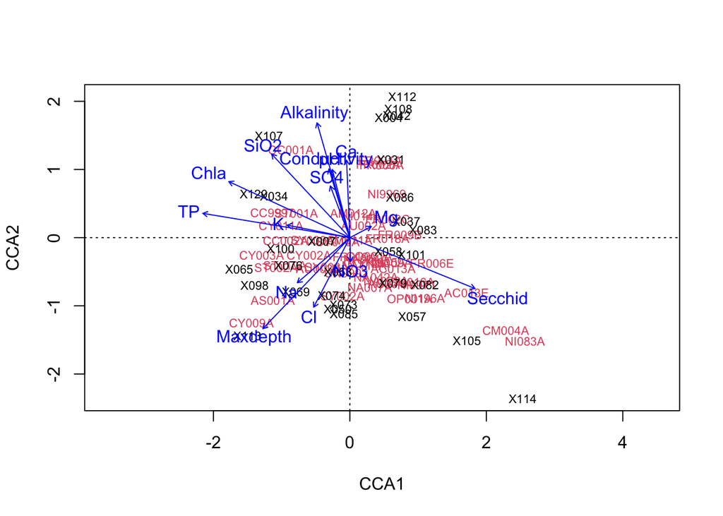

```r
plot(ponds.cca)
```

**Using the triplot, the biplot scores of the environmental variables and the ordination axes, interpret the axes in terms of environmental gradients.**

**Indicate which species are characteristic of particular types of water.**

## Comparison with un-constrained methods

Perform a CA and a DCA of the ponds diatom data:

```r
ponds.ca <- cca(diat)
ponds.ca
```

```
##
## Call: cca(X = diat)
##
##               Inertia Rank
## Total            5.81
## Unconstrained    5.81   29
##
## Inertia is scaled Chi-square
##
## Eigenvalues for unconstrained axes:
##   CA1   CA2   CA3   CA4   CA5   CA6   CA7   CA8
## 0.678 0.573 0.486 0.402 0.397 0.386 0.363 0.312
## (Showing 8 of 29 unconstrained eigenvalues)
```

```r
ponds.dca <- decorana(diat)
ponds.dca
```

```
##
## Call:
## decorana(veg = diat)
##
## Detrended correspondence analysis with 26 segments.
## Rescaling of axes with 4 iterations.
## Total inertia (scaled Chi-square): 5.812
##
##                       DCA1  DCA2  DCA3  DCA4
## Eigenvalues          0.675 0.366 0.331 0.291
## Additive Eigenvalues 0.675 0.357 0.315 0.283
## Decorana values      0.678 0.441 0.315 0.208
## Axis lengths         3.963 3.440 2.771 2.548
```

Refer to the handout on indirect ordination for hints and answer the following question:

**How does the result of the CCA compare to the results of the CA?**

**Plot the CA/DCA biplots are compare the configuration of sites in these biplots to the one shown in the CCA triplot. Do they suggest that our measured environmental variables explain the main floristic gradients in the diatom data?**

So far, you have used the default scaling (`scaling = "species"`) for the plots and summaries. Redraw the triplot using `scaling = "sites"`, to draw a triplot where the site scores are weighted averages of the species scores:

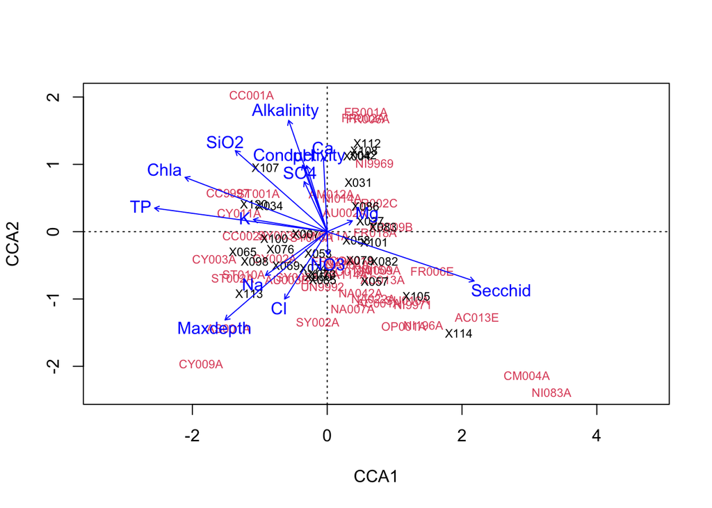

```r
plot(ponds.cca, scaling = 1)
```

**What effect does the choice of scaling have on the ordination plots?**

## Interpreting the CCA results

There is a lot more that can be done to interpret the results of the CCA and explore relationships between the diatom species and the environmental variables, as well as determining model performance for the CCA itelf.

## Outliers?

One useful diagnostic for the configuration is to identify outlier or “odd” sites or species. Plotting the Hills’s $N_2$ values for both species and samples can help visualise outliers. We can produce biplots using $N_2$ values for species and sites easily in **R** using `renyi()` in **vegan**. First we calculate the $N_2$ values for sites and species:

```r
diat.n2 <- renyi(t(diat), scales = 2, hill = TRUE)
ponds.n2 <- renyi(diat, scales = 2, hill = TRUE)
```

Then we use these values to scale the plotting symbol used to display the sites of the species and use `identify()` to label the outlier species/sites (remember to click on some species [red crosses] to label them and right click on the graph to finish). Firstly for the species:

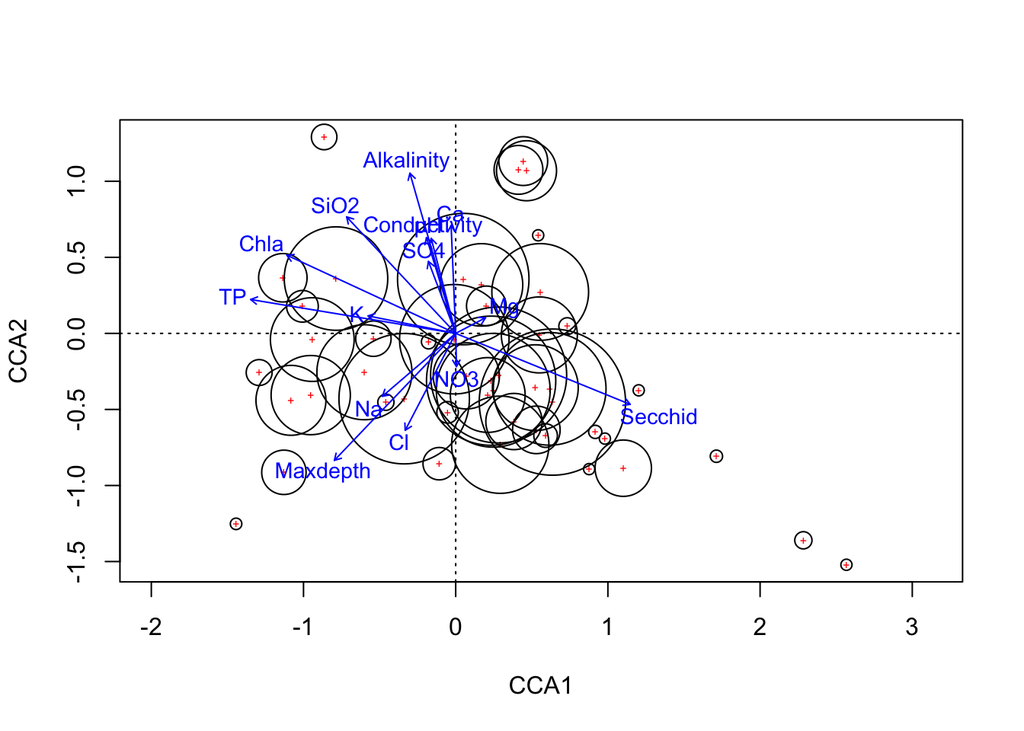

```
## integer(0)
```

```r
sppN2 <- plot(ponds.cca, display = "species", type = "n")
points(ponds.cca, display = "species", pch = "+", col = "red", cex = 0.5)
symbols(scores(ponds.cca)$species, circles = diat.n2,
        add = TRUE, inches = 0.5)
text(ponds.cca, display = "bp", arrow.mul = 2,
     col = "blue", cex = 0.9)
identify(sppN2, what = "species", ps = 10)
```

…and for the sites:

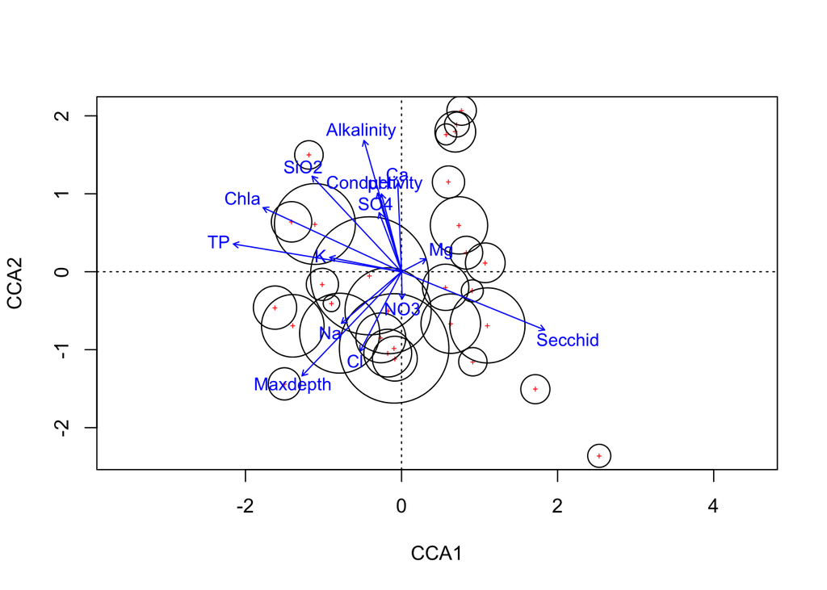

```
## integer(0)
```

```r
siteN2 <- plot(ponds.cca, display = "sites", type = "n")
points(ponds.cca, display = "sites", pch = "+", col = "red", cex = 0.5)
symbols(scores(ponds.cca)$sites, circles = ponds.n2,
        add = TRUE, inches = 0.5)
text(ponds.cca, display = "bp", arrow.mul = 2,
     col = "blue", cex = 0.9)
identify(siteN2, what = "sites", ps = 10)
```

To help interpret these plots, we add the species/site labels to the species/site Hill’s $N_2$ values and print them to the screen.

```r
names(diat.n2) <- colnames(diat)
sort(diat.n2, decreasing = TRUE)
```

```
## AC013A CO001A AM012A SY003A NA004A GO013A NI009A AM011A ST001A
## 13.087 12.172 11.761 11.671 11.565 10.186 10.082  9.795  9.259
## NA007A FR002C CY002A NI015A CC002A NI014A ST010A FR018A NA114A
##  8.703  8.655  8.503  7.677  7.491  7.379  7.088  6.799  6.691
## ST002A FR019A FR006A NI196A NA042A FR001A FR002A CC9997 NA022A
##  6.257  5.921  5.371  5.045  5.035  4.369  4.368  4.337  4.258
## AS001A AU002A SY003C SY002A CY011A CY003A CC001A AC001A UN9992
##  3.973  3.551  3.168  2.901  2.837  2.317  2.284  2.112  1.928
## CM004A FR009B AU003B SY010A SU016A AC013E CY009A FR006E NI083A
##  1.541  1.510  1.449  1.284  1.183  1.103  1.029  1.000  1.000
## NI9969 NI9971 OP001A
##  1.000  1.000  1.000
```

```r
names(ponds.n2) <- rownames(diat)
sort(ponds.n2, decreasing = TRUE)
```

```
##   X007   X073   X053   X034   X069   X082   X098   X079   X086
## 14.872 13.789 10.847 10.180 10.070  9.463  7.877  7.493  7.219
##   X074   X050   X058   X085   X065   X042   X120   X083   X037
##  6.278  6.022  5.830  5.647  5.454  5.133  5.091  5.001  4.144
##   X031   X113   X100   X112   X105   X107   X057   X108   X114
##  4.070  4.060  4.057  3.705  3.669  3.589  3.575  3.132  2.905
##   X101   X004   X076
##  2.772  2.650  2.074
```

**Using the Hill’s $N_2$ plots and the actual $N_2$ values for the sites and species, which species are abundant and which are rare in the Ponds diatom data set?**

**Which of the sites have low species diversity and which high diversity?**

### How significant are the constraints?

The CCA model we have built is a weighted, multivariate multiple regression and just as in regression, we want to achieve as parsimonious a model as possible, one that adequately describes the species environmental relationships without being overly complex. Whilst it is common for users to throw as many constraints as possible at a CCA this has the effect of *reducing* the constraints on the ordination (it becomes more like the CA the more constraints you use) and of building an overly complex model that is over fitted to that particular data set. In this section you will look at some of the model building/selection tools available within **R** and **vegan**.

Firstly, we should look for redundant constraints—environmental variables that are highly correlated with each other are prime candidates for exclusion from the model. Produce a correlation matrix of the environmental data set and calculate the variance inflation factors for each variable.

```r
cor(env) # output not shown in handout
```

```r
vif.cca(ponds.cca)
```

```
##           pH Conductivity   Alkalinity           TP         SiO2
##        7.239       30.262       16.345       10.386        5.019
##          NO3           Na            K           Mg           Ca
##        2.180       43.888        8.870       23.695        6.633
##           Cl          SO4         Chla      Secchid     Maxdepth
##       36.753       18.664        3.755        2.166        2.169
```

**Suggest which variables might be redundant and therefore dropped from the CCA model?**

We should also check the significance of the full CCA model we have fit. This is done using the `anova()` function:

```r
set.seed(42)
anova(ponds.cca)
```

[output not shown]

Note that this uses random permutations hence we set a seed.

**Is the full model significant at the 0.01 level?**

Canoco also reports the species:environment correlation—the correlation between the sites scores that are weighted averages of the species scores and the site score that are linear combinations of the environmental data. Function `spenvcor()` calculates the correlation between the two sets of site scores.

```r
spenvcor(ponds.cca)
```

```
##   CCA1   CCA2   CCA3   CCA4   CCA5   CCA6   CCA7   CCA8   CCA9
## 0.9714 0.8873 0.9369 0.8922 0.8996 0.8931 0.9119 0.8690 0.7703
##  CCA10  CCA11  CCA12  CCA13  CCA14  CCA15
## 0.8615 0.7336 0.6773 0.7731 0.6087 0.6062
```

**Are there high correlations between the two sets of site scores?**

**What does this tell you about the relationships between the species and the environmental data?**

### Foward selection and backwards elimination

Whilst automated model building methods are not the panacea that many people think they are, they can be a useful aid when model building with lots of environmental variables.

The model selection tools available in **vegan** are different to those available in CANOCO, and are based on the concept of AIC, a fairly new concept for CCA as CCA is not based on concepts of deviance and log likelihoods (from which AIC was derived). Instead features of the CCA results are converted into a deviance by calculating the Chi-square of the residual data matrix after fitting constraints (in RDA, deviance is taken to be the residual sum of squares instead). From here an AIC statistic can be calculated, the details of which are given in the reference quoted in the help page for `deviance.cca()` (type `?deviance.cca` at the **R** prompt to read this page if you so wish).

Before we begin, note that the author of **vegan**, Jari Oksanen, is not convinced about all aspects of this approach, and advocates checking the results manually—which is good advice seeing as you should not be relying on automated model selection tools anyway!

To begin, define a null model to which we will sequentially add variables in order of added importance:

```r
mod0 <- cca(diat ~ 1, data = env)
mod0
```

```
##
## Call: cca(formula = diat ~ 1, data = env)
##
##               Inertia Rank
## Total            5.81
## Unconstrained    5.81   29
##
## Inertia is scaled Chi-square
##
## Eigenvalues for unconstrained axes:
##   CA1   CA2   CA3   CA4   CA5   CA6   CA7   CA8
## 0.678 0.573 0.486 0.402 0.397 0.386 0.363 0.312
## (Showing 8 of 29 unconstrained eigenvalues)
```

As you can see, this is an unconstrained model or a CA. Function `step.cca()` is used to *step* forwards or backwards through a series of nested models adding or dropping an explanatory variable at each iteration [^1]. To use `step()` we need to define an upper and lower scope for the stepping to place over. We will use `mod0` as the lower scope and `ponds.cca` (the full model) as the upper scope when performing forward selection—this is reversed when performing backwards elimination.

```r
mod <- step(ponds.cca, scope = list(lower = formula(mod0),
                         upper = formula(ponds.cca)), test = "perm")
```

You should have seen lots of output flash across the screen. At each stage, the effect of adding/dropping a variable is evaluated in terms of a permutation test. In the above example, we used both forwards and backwards elimination at each step.

Print out the record of the steps:

```r
mod$anova
```

```
##              Step Df Deviance Resid. Df Resid. Dev   AIC
## 1                 NA       NA        14       5817 190.0
## 2            - Ca  1    272.9        15       6090 189.4
## 3  - Conductivity  1    314.1        16       6404 188.9
## 4          - Chla  1    325.5        17       6730 188.4
## 5    - Alkalinity  1    447.4        18       7177 188.3
## 6            - Na  1    492.7        19       7670 188.3
## 7            - Cl  1    313.1        20       7983 187.5
## 8           - SO4  1    473.5        21       8456 187.2
## 9          - SiO2  1    420.0        22       8876 186.7
## 10          - NO3  1    518.2        23       9395 186.4
## 11           - Mg  1    534.7        24       9929 186.1
## 12            - K  1    469.4        25      10399 185.4
## 13           - pH  1    528.3        26      10927 184.9
## 14           - TP  1    671.5        27      11599 184.7
```

We see that we started with the full model and calcium was dropped from the full model. Next Conductivity was dropped and so on, with TP being the last variable dropped. At no stage was a variable added back into the model. To view the final model simply type:

```r
mod
```

```
##
## Call: cca(formula = diat ~ Secchid + Maxdepth, data = env)
##
##               Inertia Proportion Rank
## Total           5.812      1.000
## Constrained     0.749      0.129    2
## Unconstrained   5.063      0.871   27
##
## Inertia is scaled Chi-square
##
## Eigenvalues for constrained axes:
##  CCA1  CCA2
## 0.461 0.289
##
## Eigenvalues for unconstrained axes:
##   CA1   CA2   CA3   CA4   CA5   CA6   CA7   CA8
## 0.595 0.496 0.446 0.395 0.385 0.323 0.296 0.280
## (Showing 8 of 27 unconstrained eigenvalues)
```

The final model contains two variables—secchi disk depth and maximum pond depth. Test this model and see how significant the effects of the constraints are:

```r
anova(mod)
```

```
## Permutation test for cca under reduced model
## Permutation: free
## Number of permutations: 999
##
## Model: cca(formula = diat ~ Secchid + Maxdepth, data = env)
##          Df ChiSquare  F Pr(>F)
## Model     2      0.75  2  0.001 ***
## Residual 27      5.06
## ---
## Signif. codes:  0 '***' 0.001 '**' 0.01 '*' 0.05 '.' 0.1 ' ' 1
```

**Is this model better than full model?**

**How much of the total inertia is explained by the two constraints?**

Produce a triplot of this model:

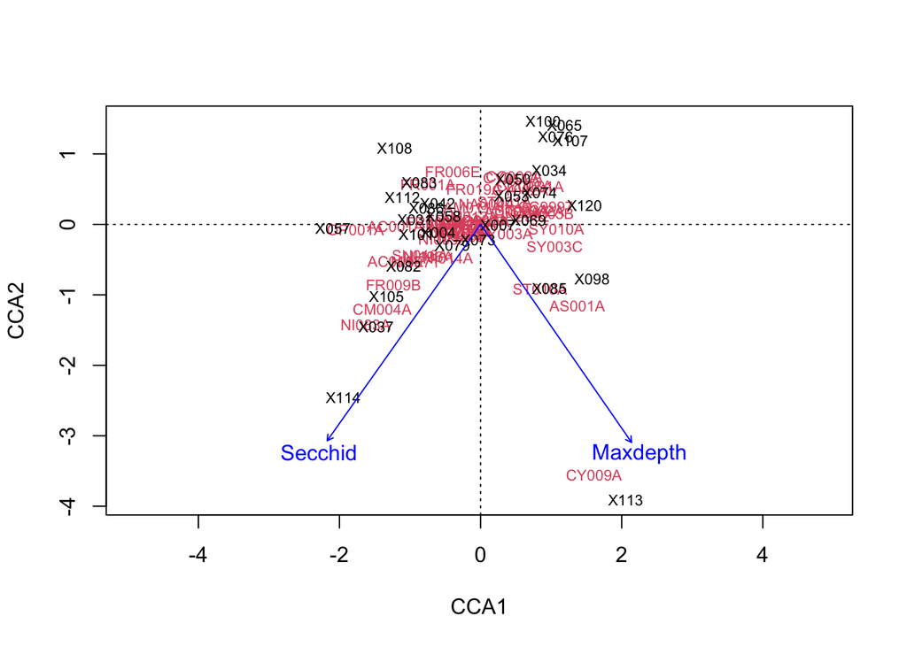

```r
plot(mod)
```

The triplot suggests that there is a strong outlier site in terms of maximum depth (Pond X113). We might wish to investigate how the CCA model might change if we deleted this observation. We delete this observation and build new null and full CCA models

```r
no.need <- which(rownames(diat) == "X113")
diat2 <- diat[-no.need, ]
env2 <- env[-no.need, ]
mod0 <- cca(diat2 ~ 1, data = env2)
cca.delete <- cca(diat2 ~ ., data = env2)
```

We can now retry the automatic stepping model selection and plot the resulting triplot:

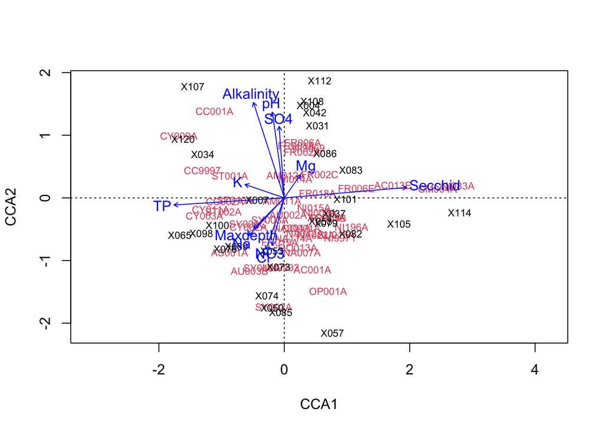

```r
mod.delete <- step(cca.delete, scope = list(lower = formula(mod0),
                   upper = formula(cca.delete)), test = "perm")
plot(mod.delete)
```

**How does this model compare to the model with MaxDepth and Secchi only?**

A further thing we should check is whether we get different models whether we do forward selection, backward elimination or both. The default for `step()` is to evaluate both forward and backward steps. If we wish to perform forward selection only, we need to tell **R** to start from the null model:

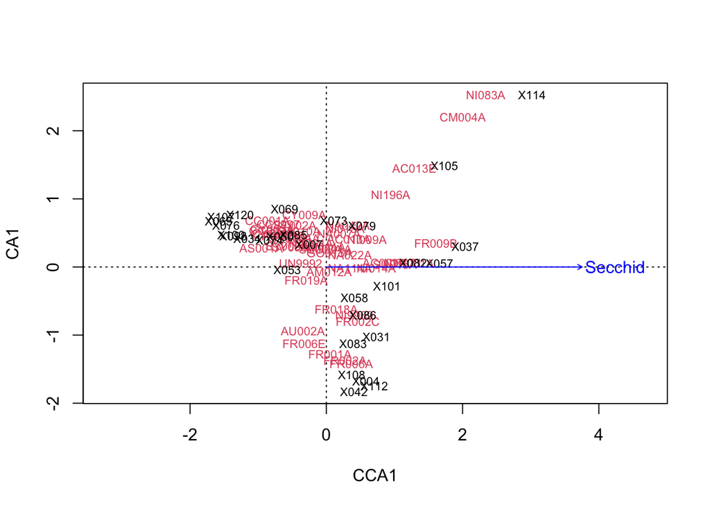

```r
mod.fwd<- step(mod0, scope = list(lower = formula(mod0),
                   upper = formula(cca.delete)), test = "perm")
plot(mod.fwd)
```

**Which variables has forward selection chosen?**

This highlights one of the problems with automatic model building tools. As a description of the data, `mod.delete` seems a nicer plot, but it retains a number environmental variables that are very correlated. Forward selection produces a model with a single environmental variable. So which to use? And therein lies the problem. There is no substitution for rolling up ones sleeves and getting involved in building and checking lots of candidate models.

As a starter, we could look at the significance of the terms in `mod.delete`:

```r
anova(mod.delete, by = "margin")
```

```
## Permutation test for cca under reduced model
## Marginal effects of terms
## Permutation: free
## Number of permutations: 999
##
## Model: cca(formula = diat2 ~ pH + Alkalinity + TP + NO3 + Na + K + Mg + Cl + SO4 + Secchid + Maxdepth, data = env2)
##            Df ChiSquare    F Pr(>F)
## pH          1     0.272 1.56  0.021 *
## Alkalinity  1     0.259 1.48  0.040 *
## TP          1     0.240 1.37  0.053 .
## NO3         1     0.222 1.27  0.136
## Na          1     0.223 1.28  0.095 .
## K           1     0.250 1.43  0.062 .
## Mg          1     0.281 1.61  0.016 *
## Cl          1     0.243 1.39  0.047 *
## SO4         1     0.237 1.35  0.085 .
## Secchid     1     0.328 1.88  0.004 **
## Maxdepth    1     0.223 1.27  0.108
## Residual   17     2.971
## ---
## Signif. codes:  0 '***' 0.001 '**' 0.01 '*' 0.05 '.' 0.1 ' ' 1
```

Here, the significance of terms are assessed marginally. A number of the environmental variables are not significant under this test. As a strategy for producing a parsimonius model, we might proceed by removing the variable that contributes the least here, NO<sub>3</sub>.

**As an exercise if you have time, try dropping out terms and rerun `anova` to try to produce a parsimonious model.**

## Step-wise selection using Adjusted $R^2$

A better way to do this for selection might be to include the adjusted $R^2$ in our evaluations of the changes to the models we make as we sequentially add or remove terms from the model. The function `ordiR2step()` does this for us, in which we not only add a variable if it significantly improves the model, but we also compare against the $R^2_{\text{adjusted}}$ of the model at the upper scope

```r
mod.r2step <- ordiR2step(mod0, scope = formula(cca.delete))
```

```
## Step: R2.adj= 0
## Call: diat2 ~ 1
##
##                 R2.adjusted
## <All variables>   0.0863435
## + Secchid         0.0410362
## + TP              0.0318548
## + Chla            0.0268447
## + SiO2            0.0156762
## + Alkalinity      0.0116020
## + pH              0.0075948
## + NO3             0.0075628
## + Maxdepth        0.0048095
## + K               0.0017550
## + Ca              0.0017361
## + Cl              0.0001815
## <model>           0.0000000
## + Na             -0.0002425
## + Mg             -0.0013436
## + Conductivity   -0.0018127
## + SO4            -0.0073961
##
##           Df AIC    F Pr(>F)
## + Secchid  1 177 2.18  0.002 **
## ---
## Signif. codes:  0 '***' 0.001 '**' 0.01 '*' 0.05 '.' 0.1 ' ' 1
##
## Step: R2.adj= 0.0412
## Call: diat2 ~ Secchid
##
##                 R2.adjusted
## <All variables>     0.08634
## + TP                0.06301
## + Alkalinity        0.05558
## + SiO2              0.05211
## + pH                0.05197
## + NO3               0.05128
## + Maxdepth          0.04795
## + Chla              0.04583
## + Ca                0.04394
```

[output cut: 22 more lines]

```
## + K                 0.06647
## + Ca                0.06609
## + SiO2              0.06359
## + Conductivity      0.06284
## <model>             0.06257
## + Cl                0.05999
## + Na                0.05934
## + SO4               0.05809
## + Mg                0.05795
## + Chla              0.05316
##
##              Df AIC    F Pr(>F)
## + Alkalinity  1 178 1.39  0.066 .
## ---
## Signif. codes:  0 '***' 0.001 '**' 0.01 '*' 0.05 '.' 0.1 ' ' 1
```

```r
mod.r2step
```

```
##
## Call: cca(formula = diat2 ~ Secchid + TP, data = env2)
##
##               Inertia Proportion Rank
## Total           5.582      1.000
## Constrained     0.720      0.129    2
## Unconstrained   4.862      0.871   26
##
## Inertia is scaled Chi-square
##
## Eigenvalues for constrained axes:
##  CCA1  CCA2
## 0.526 0.194
##
## Eigenvalues for unconstrained axes:
##   CA1   CA2   CA3   CA4   CA5   CA6   CA7   CA8
## 0.625 0.476 0.400 0.394 0.371 0.315 0.284 0.276
## (Showing 8 of 26 unconstrained eigenvalues)
```

```r
mod.r2step$anova
```

```
##                 R2.adj Df AIC    F Pr(>F)
## + Secchid       0.0412  1 177 2.18  0.002 **
## + TP            0.0626  1 177 1.62  0.020 *
## <All variables> 0.0863
## ---
## Signif. codes:  0 '***' 0.001 '**' 0.01 '*' 0.05 '.' 0.1 ' ' 1
```

**Which terms have been retained in this model?**

**Does this differ from the previous step-wise selection?**

**Using `anova()` test the individual marginal effects of the terms retained in `mod.r2step`. Do all the terms have statistically significant marginal effects?**

## Partial CCA models

There are occasions where we might wish to fit a model to our species data after controlling for the effects of one or more environmental variables. These models are known as partial constrained ordinations—the effect of the one or more environmental variables are partialled out, and a CCA/RDA model is applied to explain the residual variation.

In **vegan** partial models are fitted using the `Condition()` function within the model formula describing the model you wish to fit. The `Condition()` function is used to *condition* the model on the set of covariables and fit a model to the residuals of the conditioned model. Multiple variables can be included within `Condition()`, separated by a `+`. Partial models can also be used to evaluate the significance of adding a new variable to a model already containing one or more variables—partial out the existing variables and fit a model with the new variable of interest, using `anova()` to assess the effect of adding this new variable.

Say we were interested in investigating the effects of the hydrochemical variables on diatom distributions in the Ponds dataset, after controlling for the effects of `Maxdepth` and `Secchid`, we would fit this model in **R** like so:

```r
partial.mod <- cca(diat ~ . + Condition(Maxdepth + Secchid), data = env)
```

```
##
## Some constraints or conditions were aliased because they were
## redundant. This can happen if terms are constant or linearly
## dependent (collinear): 'Secchid', 'Maxdepth'
```

```r
partial.mod
```

```
##
## Call: cca(formula = diat ~ pH + Conductivity + Alkalinity +
## TP + SiO2 + NO3 + Na + K + Mg + Ca + Cl + SO4 + Chla +
## Secchid + Maxdepth + Condition(Maxdepth + Secchid), data =
## env)
##
##               Inertia Proportion Rank
## Total           5.812      1.000
## Conditional     0.749      0.129    2
## Constrained     2.524      0.434   13
## Unconstrained   2.539      0.437   14
##
## Inertia is scaled Chi-square
##
## -- NOTE:
## Some constraints or conditions were aliased because they
## were redundant. This can happen if terms are constant or
## linearly dependent (collinear): 'Secchid', 'Maxdepth'
##
## Eigenvalues for constrained axes:
##  CCA1  CCA2  CCA3  CCA4  CCA5  CCA6  CCA7  CCA8  CCA9 CCA10
## 0.397 0.369 0.328 0.277 0.206 0.205 0.163 0.151 0.146 0.105
## CCA11 CCA12 CCA13
## 0.080 0.054 0.042
##
## Eigenvalues for unconstrained axes:
##   CA1   CA2   CA3   CA4   CA5   CA6   CA7   CA8   CA9  CA10
## 0.445 0.316 0.287 0.246 0.239 0.205 0.174 0.149 0.119 0.103
##  CA11  CA12  CA13  CA14
## 0.085 0.084 0.052 0.035
```

```r
anova(partial.mod)
```

```
## Permutation test for cca under reduced model
## Permutation: free
## Number of permutations: 999
##
## Model: cca(formula = diat ~ pH + Conductivity + Alkalinity + TP + SiO2 + NO3 + Na + K + Mg + Ca + Cl + SO4 + Chla + Secchid + Maxdepth + Condition(Maxdepth + Secchid), data = env)
##          Df ChiSquare    F Pr(>F)
## Model    13      2.52 1.07   0.98
## Residual 14      2.54
```

**Do the remaining environmental variables explain significant amounts of the variance in the species data after controlling for `Maxdepth` and `Secchid`?**

**How much of the variance is explained by the Conditional variables?**

**How much of the variance is explained by the constraints?**

**How much is left unexplained?**

Finally, plot a triplot for this model:

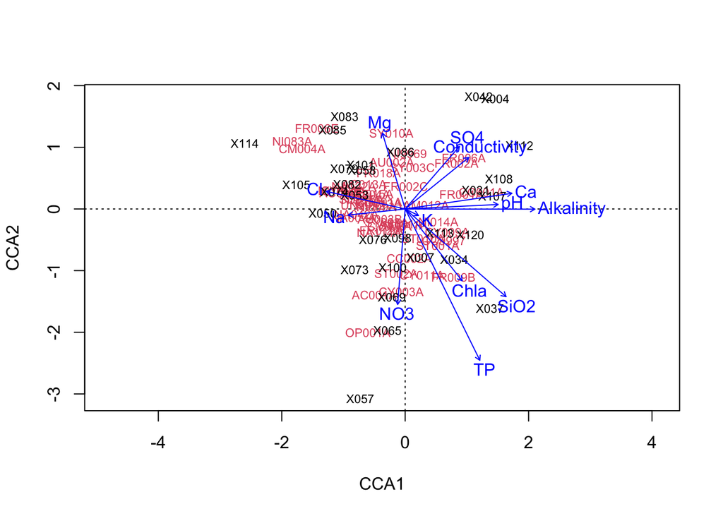

```r
plot(partial.mod)
```

# Birds Data

This data set is on bird assemblages in a montane forest in the Velka Fatra Mountains (Slovak Republic).

```r
library("readr")
library("tidyr")
library("dplyr")
library("tibble")
```

We can load the bird data and process it into two data sets

1. the species abundances, and
2. the associated environmental variables.

```r
birds_url <- "https://bit.ly/maed-birds"

birds <- read_csv(birds_url, na = "", skip = 1)
```

[output not shown]

```r
birds_spp <- birds %>%
    mutate(across(AegiCaud:OriOri, ~ replace_na(.x, 0))) %>%
    column_to_rownames("...1")
birds_spp <- birds_spp[, 1:36]

birds_env <- birds %>%
    select(c("...1", Altit:Expos)) %>%
    mutate(Rocks = factor(Rocks), Expos = factor(Expos),
    across(Forest:Slope, ~ ordered(.x))) %>%
    column_to_rownames("...1")
```

The variables are:

- Altitude
- Forest cover
- Forest density
- Amount of broad leaf trees
- E2 layer (scrub layer cover)
- E2 layer conifers
- E1 layer (herb layer cover)
- E1 height
- Slope
- Presence of rocks
- Exposure

The aim of the analysis is to fit a constrained ordination to these data, to identify which of the predictor variables seem to have the best ability to explain variation in bird data.

[^1]: `step()` is a generic function and `step` methods can be written for different modelling functions. This means you only need to use the generic `step()` and **R** take care of finding and using the correct method for the object you are running `step()` on. Another example of a generic is `anova()`, which you used earlier—what you actually used was `anova.cca()`